# MultiChannel Gift Company Sales Campaign and Sales Data Analysis

### Step 3. combine orders with contacts to gain overall sight of training dataset

```
CREATE OR REPLACE VIEW overall_contact_res2 AS(
SELECT rfmi_cell,train_df2."Cust_ID",responded_contact_num, responded_order_num, not_responded_contact_num
    FROM train_df2
    LEFT JOIN rfmi
    ON train_df2."Cust_ID" = rfmi."Cust_ID"
    LEFT JOIN
        (SELECT "Cust_ID", COUNT("ContactDate") AS responded_contact_num, SUM(order_related) AS responded_order_num
        FROM contact_ordernum
        WHERE "Cust_ID" IN (SELECT * FROM train_df2)
        AND order_related > 0
        GROUP BY "Cust_ID") AS responded_contact
    ON train_df2."Cust_ID" = responded_contact."Cust_ID"
    LEFT JOIN
        (SELECT "Cust_ID", COUNT("ContactDate") AS not_responded_contact_num
        FROM contact_ordernum
        WHERE "Cust_ID" IN (SELECT * FROM train_df2)
        AND order_related = 0
        GROUP BY "Cust_ID") AS not_responded_contact
    ON train_df2."Cust_ID" = not_responded_contact."Cust_ID")
```

```python
overall_contact_res2 = pd.read_sql_query('SELECT * FROM overall_contact_res2',engine)
overall_contact_res2 = overall_contact_res2.fillna(0)
overall_contact_res2["total_contact_num"] = overall_contact_res2.responded_contact_num + overall_contact_res2.not_responded_contact_num
overall_contact_res2 = overall_contact_res2[['Cust_ID', 'rfmi_cell', 'responded_contact_num',
       'not_responded_contact_num','total_contact_num','responded_order_num']]


overall_contact_res2["respond_or_not"] = overall_contact_res2.responded_order_num.apply(binary)
overall_contact_res2["contact_or_not"] = overall_contact_res2.total_contact_num.apply(binary)
overall_contact_res2["mail_cost"] = overall_contact_res2.total_contact_num*1
overall_contact_res2["order_profit"] = overall_contact_res2.responded_order_num * 30
overall_contact_res2.to_sql('overall_contact_res_new2',engine,if_exists='replace',index=False)
```

```
CREATE OR REPLACE VIEW rfmi_tpm AS(
SELECT rfmi_cell, COUNT(DISTINCT "Cust_ID") AS seg_cust_num,
        SUM(contact_or_not) AS cont_cust, SUM(respond_or_not) AS res_cust,
        SUM(responded_contact_num) AS seg_total_responded_contact, SUM(total_contact_num) AS seg_total_contact,
        SUM(mail_cost) AS seg_total_cost, SUM(order_profit) AS seg_total_profit
        FROM overall_contact_res_new2
        GROUP BY rfmi_cell
        ORDER BY rfmi_cell DESC)
```

```python
rfmi_tpm = pd.read_sql_query('SELECT * FROM rfmi_tpm',engine)
rfmi_tpm["contact_rate"] = rfmi_tpm.cont_cust/rfmi_tpm.seg_cust_num
rfmi_tpm["cont_response_rate"] = rfmi_tpm.seg_total_responded_contact/rfmi_tpm.seg_total_contact
rfmi_tpm["seg_roi"] = rfmi_tpm.seg_total_profit/rfmi_tpm.seg_total_cost
rfmi_tpm["seg_total_gain"] = rfmi_tpm.seg_total_profit - rfmi_tpm.seg_total_cost
rfmi_tpm = rfmi_tpm.sort_values(by='cont_response_rate',axis = 0,ascending = False)
rfmi_tpm["cumsum_gain"] = rfmi_tpm.seg_total_gain.cumsum()
rfmi_tpm = rfmi_tpm.reset_index(drop = True)
rfmi_tpm = rfmi_tpm[['rfmi_cell', 'seg_cust_num', 'cont_cust', 'contact_rate', 'res_cust',
       'seg_total_responded_contact', 'seg_total_contact', 'cont_response_rate', 'seg_total_cost',
       'seg_total_profit', 'seg_roi', 'seg_total_gain', 'cumsum_gain']]
rfmi_tpm.to_sql('rfm_overall_summary',engine,if_exists='replace',index=False)
```

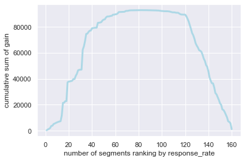

```python
plt.plot(range(1,161), rfmi_tpm.iloc[:160,:].cumsum_gain, color='lightblue', linewidth=3)
plt.ylabel("cumulative sum of gain")
plt.xlabel("number of segments ranking by response_rate")
```

```python
optimal2 = rfmi_tpm.cumsum_gain.idxmax()+1
print("The optimal gain will be reached when we take the first %f segments"%(optimal2))
optimal_list2 = list(rfmi_tpm.rfmi_cell)[:optimal2]
print("And the concrete segments are shown as following:")
print(optimal_list2)
```

[output not shown]

```python
target_cell2 = rfmi_tpm[['rfmi_cell', 'cont_response_rate']][:optimal2]
target_cell2.to_sql('target2',engine,if_exists='replace',index=False)
```

```
CREATE OR REPLACE VIEW sub_rfmi AS(
SELECT test_df2."Cust_ID", target2.rfmi_cell FROM
target2 INNER JOIN rfmi
ON target2.rfmi_cell = rfmi.rfmi_cell
INNER JOIN test_df2
ON test_df2."Cust_ID" = rfmi."Cust_ID"
)

CREATE OR REPLACE VIEW test_contact_res2 AS(
SELECT rfmi_cell,sub_rfmi."Cust_ID",responded_contact_num, responded_order_num, not_responded_contact_num
    FROM sub_rfmi
    LEFT JOIN
        (SELECT "Cust_ID", COUNT("ContactDate") AS responded_contact_num, SUM(order_related) AS responded_order_num
        FROM contact_ordernum
        WHERE order_related > 0
        GROUP BY "Cust_ID") AS responded_contact
    ON sub_rfmi."Cust_ID" = responded_contact."Cust_ID"
    LEFT JOIN
        (SELECT "Cust_ID", COUNT("ContactDate") AS not_responded_contact_num
        FROM contact_ordernum
        WHERE order_related = 0
        GROUP BY "Cust_ID") AS not_responded_contact
    ON sub_rfmi."Cust_ID" = not_responded_contact."Cust_ID")
```

### 4. Validation

```python
test_contact_res2 = pd.read_sql_query('SELECT * FROM test_contact_res2',engine)
test_contact_res2 = test_contact_res2.fillna(0)
test_contact_res2["total_contact_num"] = test_contact_res2.responded_contact_num + test_contact_res2.not_responded_contact_num
test_contact_res2 = test_contact_res2[['Cust_ID', 'rfmi_cell', 'responded_contact_num',
       'not_responded_contact_num','total_contact_num','responded_order_num']]

test_contact_res2["respond_or_not"] = test_contact_res2.responded_order_num.apply(binary)
test_contact_res2["contact_or_not"] = test_contact_res2.total_contact_num.apply(binary)
test_contact_res2["mail_cost"] = test_contact_res2.total_contact_num*1
test_contact_res2["order_profit"] = test_contact_res2.responded_order_num * 30
test_contact_res2.to_sql('test_contact_res_new2',engine,if_exists='replace',index=False)
```

```python
sum(test_contact_res2.total_contact_num) < budget # contact number in test set
```

```
True
```

```python
test_contact_res2.shape[0] < budget #customer number in test set
```

```
True
```

```
CREATE OR REPLACE VIEW rfmi_test AS(
SELECT rfmi_cell, COUNT(DISTINCT "Cust_ID") AS seg_cust_num,
        SUM(contact_or_not) AS cont_cust, SUM(respond_or_not) AS res_cust,
        SUM(responded_contact_num) AS seg_total_responded_contact, SUM(total_contact_num) AS seg_total_contact,
        SUM(mail_cost) AS seg_total_cost, SUM(order_profit) AS seg_total_profit
        FROM test_contact_res_new2
        GROUP BY rfmi_cell
        ORDER BY rfmi_cell DESC)
```

```python
rfmi_val = pd.read_sql_query('SELECT * FROM rfmi_test',engine)
rfmi_val["contact_rate"] = rfmi_val.cont_cust/rfmi_val.seg_cust_num
rfmi_val["cont_response_rate"] = rfmi_val.seg_total_responded_contact/rfmi_val.seg_total_contact
rfmi_val["seg_roi"] = rfmi_val.seg_total_profit/rfmi_val.seg_total_cost
rfmi_val["seg_total_gain"] = rfmi_val.seg_total_profit - rfmi_val.seg_total_cost
rfmi_val = rfmi_val.sort_values(by='cont_response_rate',axis = 0,ascending = False)
rfmi_val["cumsum_gain"] = rfmi_val.seg_total_gain.cumsum()
rfmi_val = rfmi_val.reset_index(drop = True)
rfmi_val = rfmi_val[['rfmi_cell', 'seg_cust_num', 'cont_cust', 'contact_rate', 'res_cust',
       'seg_total_responded_contact', 'seg_total_contact', 'cont_response_rate', 'seg_total_cost',
       'seg_total_profit', 'seg_roi', 'seg_total_gain', 'cumsum_gain']]
rfmi_val.to_sql('rfmi_validation_summary',engine,if_exists='replace',index=False)
```

```python
print("Before adding Interaction dimension, our average response rate per RFM framework is %f %% while after that, it raised to %f %%"%(np.mean(rfm_val.cont_response_rate)*100,np.mean(rfmi_val.cont_response_rate)*100))
```

```
Before adding Interaction dimension, our average response rate per RFM framework is 4.515988 % while after that, it raised to 7.256018 %
```

```python
post_roi_rfmi = sum(rfmi_val.seg_total_profit)/sum(rfmi_val.seg_total_cost)
print("Before adding Interaction dimension, our overall ROI is %f while after that, it raised to %f"%(post_roi, post_roi_rfmi))
```

```
Before adding Interaction dimension, our overall ROI is 1.430525 while after that, it raised to 2.286793
```

# Conclusion

After performing an in-depth analysis on the dataset, we were able to derive a list of meaningful insights. First, we discovered that phone has been a dominant method for sales whereas internet orders increase day by day and crosses sales by phone for the first time in 2007. We also noticed that store purchasing is least impacted by seasonality. Nevertheless, Christmas shows a highest amount of sales for the company.

We also noticed that catalog marketing has a stable patterns over years whereas e-mail marketing shows no such pattern. It also came to our attention that from a per response perspective, average spending per response and average items purchased tend to be higher for catalog shopping as compared to email shopping, whereas the average number of order placed per response tend to be higher for email marketing.

# References

- https://pandas.pydata.org/pandas-docs/stable/
- https://docs.sqlalchemy.org/
- http://initd.org/psycopg/docs/